# L07 Layers

Data Visualization (STAT 302)

Author

Lauren Kennedy

## Overview

The goal of this lab is to explore more plots in `ggplot2` and continue to leverage the use of various layers to build complex and well annotated plots.

## Datasets

We’ll be using the `tech_stocks.rda` dataset which is already in the `/data` subdirectory in our **data_vis_labs** project.

We have a new dataset, `NU_admission_data.csv`, which will need to be downloaded and added to our `/data` subdirectory.

We will also be using the `mpg` dataset which comes packaged with `ggplot2` — use `?ggplot2::mpg` to access its codebook.

```r
# load package(s)
library(tidyverse)
library(janitor)
library(lubridate)
library(patchwork)

# load datasets
load("data/tech_stocks.rda")
admin_dat <- read.csv("data/NU_admission_data.csv") %>% clean_names()
```

## Exercise 1

Using `mpg` and the `class_dat` dataset created below, recreate the following graphic as precisely as possible in two different ways.

*Hints:*

- Transparency is 0.6
- Horizontal spread is 0.1
- Larger points are 5
- Larger points are “red”

```r
# additional dataset for plot
class_dat <- mpg |>
  group_by(class) |>
  summarise(
    n = n(),
    mean_hwy = mean(hwy),
    label = str_c("n = ", n, sep = "")
  )
```

### Plot 1 – using `mean_hwy`

**Tip**

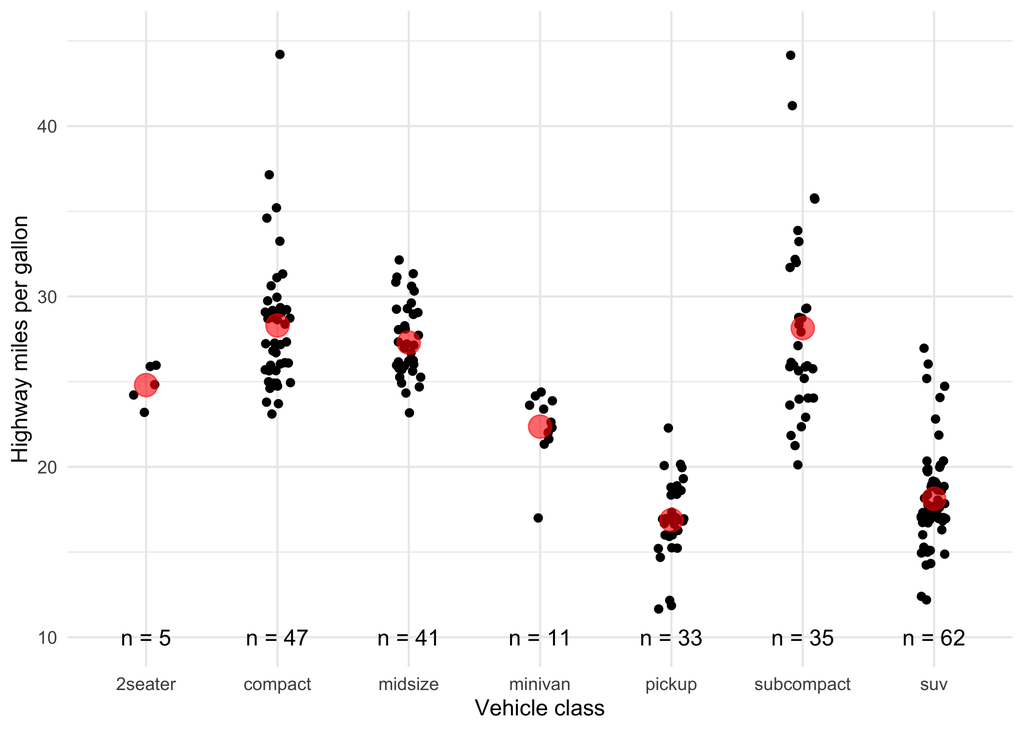

```r
ggplot(mpg, aes(class, hwy)) +
  geom_jitter(width = 0.1) +
  geom_point(data = class_dat,
             aes(y = mean_hwy),
             color = "red",
             size = 5,
             alpha = 0.6) +
  theme_minimal() +
  ylim(c(10,45)) +
  labs(
    x = "Vehicle class",
    y = "Highway miles per gallon"
  ) +
  geom_text(data = class_dat,
            aes(y = 10, label = label))
```

### Plot 2 – not using `mean_hwy`

**Solution**

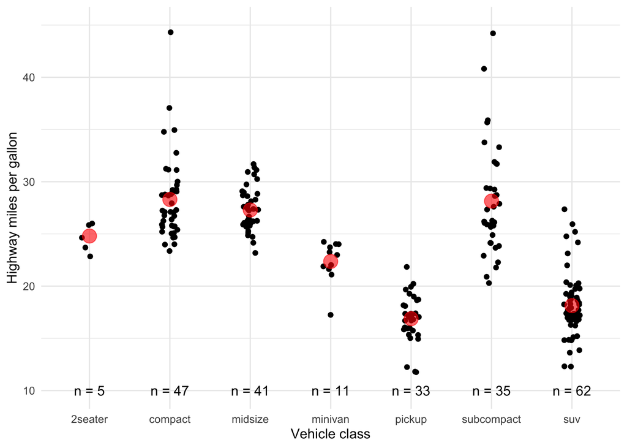

```r
ggplot(mpg, aes(class, hwy)) +
  geom_jitter(width = 0.1) +
  geom_point(
    stat = "summary",
    fun = mean,
    color = "red",
    size = 5,
    alpha = 0.6) +
  theme_minimal() +
  ylim(c(10,45)) +
  labs(
    x = "Vehicle class",
    y = "Highway miles per gallon"
  ) +
  geom_text(data = class_dat,
            aes(y = 10, label = label))
```

## Exercise 2

Using the `perc_increase` dataset derived from the `tech_stocks` dataset, recreate the following graphic as precisely as possible.

*Hints:*

- Hex color code `#56B4E9`
- Justification of 1.1
- Size is 5

```r
# percentage increase data
perc_increase <- tech_stocks |>
  arrange(desc(date)) |>
  distinct(company, .keep_all = TRUE) |>
  mutate(
    perc = 100 * (price - index_price) / index_price,
    label = str_c(round(perc), "%", sep = ""),
    company = fct_reorder(factor(company), perc)
  )
```

**Solution**

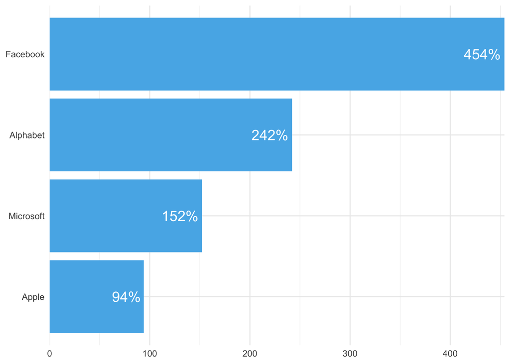

```r
ggplot(perc_increase, aes(y = company, x = perc)) +
  geom_col(fill = "#56B4E9") +
  theme_minimal() +
  xlab(NULL) +
  ylab(NULL) +
  geom_text(data = perc_increase, aes(y = company, label = label), hjust = 1.1,
            size = 5, color = "white") +
  scale_x_continuous(expand = c(0,0))
```

## Exercise 3

**Warning**

Some thoughtful data wrangling will be needed and it will be demonstrated in class — **Do not expect a video**.

Examine the data and the plot provided in `undergraduate-admissions-statistics.pdf` — this pdf was collected from the [Northwestern Data Book webpage](https://www.adminplan.northwestern.edu/ir/data-book/). As you can see they have overlaid two plot types on one another by using dual y-axes.

There is one major error they make with the bars in their graphic. **Explain what it is.**

**Solution**

The major error is that the plot overcounts students. The green bar represents the total applications; the red represents how many admitted students there are; and the blue is how many students matriculate. However, the matriculants are counted 3 times in this stack and the admitted students are counted twice.

Using `NU_admission_data.csv`[^1], create **two separate plots** that display the same information instead of trying to put it all in one single plot — **stack them** using `patchwork` or `cowplot`.

<sup>1</sup> Data is taken from the pdf. The file includes a few extra years.

Which approach do you find communicates the information better, the single dual y-axes plot or the two separate plot approach? **Why?**

*Hints:*

- Form 4 datasets (helps you get organized, but not entirely necessary):
  - 1 that has bar chart data,
  - 1 that has bar chart label data,
  - 1 that has line chart data, and
  - 1 that has line chart labels
- Consider using `ggsave()` to save the image with a fixed size so it is easier to pick font sizes.

**Solution**

```r
bar_dat <- admin_dat %>%
  filter(year >= 2002) %>%
  mutate(
    cat_a = applications - admitted_students,
    cat_b = admitted_students - matriculants,
    cat_c = matriculants
  ) %>%
  select(year, contains("cat_")) %>%
  pivot_longer(
    cols = -year,
    names_to = "category",
    values_to = "value"
  )

bar_labels <- admin_dat %>%
  filter(year >= 2002) %>%
  select(-contains("rate")) %>%
  pivot_longer(
    cols = -year,
    names_to = "category",
    values_to = "value"
  ) %>%
  mutate(
    col_label = prettyNum(value, big.mark = ",")
  )

plot_1 <- ggplot(data = bar_dat, aes(factor(year), value)) +
  geom_col(aes(fill = category), width = 0.6) +
  theme_minimal() +
  geom_text(
    data = bar_labels,
    aes(label = col_label),
    size = 2.5,
    color = "black",
    fontface = "bold"
  ) +
  labs(
    x = "Entering Year",
    y = "Applications",
    title = "Northwestern University \nUndergraduate Admissions 2001-2021"
  ) +
  theme(
    plot.title = element_text(hjust = 0.5),  # Center the title
    legend.position = "top"
) +
  scale_x_discrete(breaks = unique(bar_dat$year)) +

  scale_fill_manual(
    values = c("cat_a" = "#4CAF50", "cat_b" = "#F44336", "cat_c" = "#2196F3"),
    labels = c("cat_a" = "Applications", "cat_b" = "Admitted students", "cat_c" = "Matriculants"),
               name = NULL)



#ggsave("plot_1.png", plot = plot_1, width = 10, height = 7, dpi = 300)
```

```r
rate_dat <- admin_dat %>%
  filter(year >= 2002) %>%
  select(year, contains("_rate")) %>%
  pivot_longer(
    cols = -year,
    names_to = "category",
    values_to = "value"
  )

rate_labels <- admin_dat %>%
  filter(year >= 2002) %>%
  select(year, contains("_rate")) %>%
  pivot_longer(
    cols = -year,
    names_to = "category",
    values_to = "value"
  ) %>%
  mutate(
    pct_label = str_c(value, '%'),
    value = case_when(
      category == "yield_rate" ~ value + 2,
      category == "admission_rate" ~ value -2
    )
  )


plot_2 <- ggplot(data = rate_dat, aes(year, value)) +
  geom_line(aes(color = category)) +
  geom_point(data = rate_dat,
             aes(color = category, shape = category),
             size = 2) +
  scale_shape_manual(values = c("yield_rate" = 8, "admission_rate" = 15),
                     labels = c("yield_rate" = "Yield Rate", "admission_rate" = "Admission Rate"),
                     name = NULL) +
  scale_color_manual(values = c("yield_rate" = "#2196F3", "admission_rate" = "#F44336"),
                     labels = c("yield_rate" = "Yield Rate", "admission_rate" = "Admission Rate"),
                     name = NULL) +
  theme_minimal() +
  geom_text(
    data = rate_labels,
    aes(label = pct_label),
    size = 2.5,
    color = "black",
    fontface = "bold"
  ) +
  theme(
    legend.position = 'top',
    panel.grid.minor.x = element_blank()
  ) +
  labs(
    x = "Entering Year",
    y = "Rate"
  ) +
  scale_x_continuous(breaks = seq(2002, 2022, by = 1)) +
  scale_y_continuous(labels = function(x) paste0(x, "%"))

#ggsave("plot_2.png", plot = plot_2, width = 10, height = 7, dpi = 300)
```

```r
ggsave("stacked_plot.png",
       plot_1/plot_2, # or use patchwork with plot_1 / plot_2
       width = 8,  # Width in inches
       height = 10, # Height in inches
       dpi = 300)
```

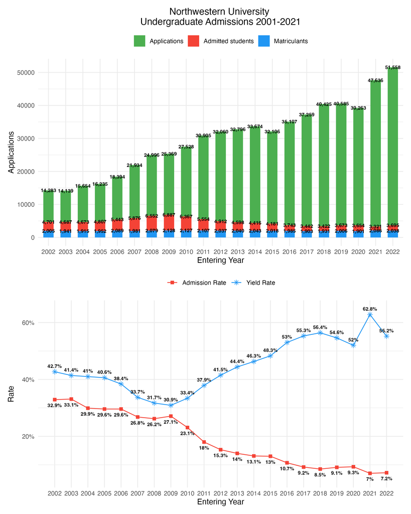